# Projekt zaliczeniowy

Wybrane pakiety do analizy danych 2025

Nazwisko i imię, numer indeksu

05 styczeń, 2026

# Wybór i opis zbioru danych

Dostępnych jest 10 zbiorów danych. Do opracowania należy wybrać ten, którego numer jest równy **ostatniej cyfrze numeru indeksu**

Zbiór danych zawiera następujące informacje o ofertach sprzedaży mieszkań. Poniżej zestawienie danych i ich opis.

1. `Id_oferty`: Unikalny identyfikator oferty
2. `cena`: Cena mieszkania w PLN
3. `powierzchnia`: Powierzchnia mieszkania w metrach kwadratowych
4. `dzielnica`: Jedna z 5 analizowanych dzielnic
5. `l_pokoi`: Liczba pokoi w mieszkaniu
6. `odleglosc_od_sklepu`: Odległość od najbliższego dyskontu w metrach
7. `odleglosc_od_przystanku`: Odległość od najbliższego przystanku komunikacji miejskiej
8. `pietro`: Klasyfikacja pięter jako parter, ostatnie piętro lub pośrednie piętro
9. `parking`: 0 – brak miejsca postojowego lub parkingu, 1 – jest miejsce postojowe lub parking
10. `winda`: 0 dla braku windy, 1 gdy winda jest w budynku

# Przygotowanie danych

## Zadania

- W pierwszym polu umieść wszystkie biblioteki używane w projekcie.
- Załaduj dane (kod, bez kreatora) i przekształć zmienne jakościowe na typ `factor`.
- Wyświetl podsumowanie danych. Na podstawie tego określ, które zmienne są jakościowe, a które ilościowe.

## Rozwiązania

```r
#install.packages("openxlsx")
library(ggplot2) #to na pewno się przyda
library(openxlsx)
library(Hmisc)
library(Przewodnik)
library(fitdistrplus)
library(lmtest)
library("car")
library(moments)
```

```r
dane = read.xlsx("C://Users//Rozalka//Desktop//mieszkania8.xlsx", sheet=1)
head(dane)
```

```
##   id_oferty      cena powierzchnia   dzielnica l_pokoi odleglosc_od_sklepu
## 1    PFXKYR  578424.9        36.34     Debniki       2                 150
## 2    VVQAHH  655584.2        40.29 StareMiasto       2                 215
## 3    UZZLXQ  985890.0        83.24    NowaHuta       4                 106
## 4    ZVFZLN 1307662.5        84.52     Debniki       4                 159
## 5    XUIMQB  563257.7        29.98   Bronowice       1                 178
## 6    YFMJLG  516782.7        33.66     Debniki       2                 160
##   odleglosc_od_przystanku   pietro parking winda
## 1                     644 ostatnie       1     1
## 2                     283   parter       0     0
## 3                     872   parter       0     1
## 4                     738 ostatnie       1     1
## 5                     626 ostatnie       0     1
## 6                     827 ostatnie       1     1
```

```r
dane$dzielnica = as.factor(dane$dzielnica)
dane$pietro = as.factor(dane$pietro)
dane$parking = as.factor(dane$parking)
dane$winda = as.factor(dane$winda)

summary(dane)
```

```
##   id_oferty              cena          powierzchnia           dzielnica
##  Length:2000        Min.   : 226970   Min.   : 20.09   Bronowice   :508
##  Class :character   1st Qu.: 495225   1st Qu.: 31.45   Debniki     :578
##  Mode  :character   Median : 749632   Median : 47.36   NowaHuta    :465
##                     Mean   : 854919   Mean   : 55.47   PradnikBialy: 70
##                     3rd Qu.:1181849   3rd Qu.: 79.33   StareMiasto :379
##                     Max.   :2180360   Max.   :111.63
##                     NA's   :11        NA's   :9
##     l_pokoi      odleglosc_od_sklepu odleglosc_od_przystanku       pietro
##  Min.   :1.000   Min.   : 67.0       Min.   : 181.0          ostatnie :642
##  1st Qu.:2.000   1st Qu.:114.0       1st Qu.: 593.5          parter   :691
##  Median :2.000   Median :159.0       Median : 759.0          posrednie:662
##  Mean   :2.633   Mean   :158.3       Mean   : 804.9          NA's     :  5
##  3rd Qu.:4.000   3rd Qu.:196.0       3rd Qu.: 968.5
##  Max.   :5.000   Max.   :273.0       Max.   :1615.0
##  NA's   :7       NA's   :10          NA's   :5
##  parking      winda
##  0   : 816   0   : 316
##  1   :1176   1   :1669
##  NA's:   8   NA's:  15
##
##
##
##
```

```
Zmiennymi jakościowymi są dzielnica, pietro, parking oraz winda. Zmiennymi ilościowymi są odleglosc_od_sklepu, cena, powierzchnia, l_pokoi oraz odleglosc_od_przystanku.
```

# Obsługa brakujących danych

## Zadania

Sprawdź, czy w zestawie danych występują wartości `NA`. Jeśli tak:

- Dla zmiennych jakościowych zastąp brakujące wartości najczęściej występującą kategorią.
- Dla zmiennych ilościowych zastąp brakujące wartości średnią.
- Ze względu na działanie funkcji `impute` może być przydatna ponowna konwersja na odpowiedni typ zmiennej.

## Rozwiązania

```r
tab_licz1 = table(dane$pietro)
d1 = names(which.max(tab_licz1))

tab_licz2 = table(dane$parking)
d2 = names(which.max(tab_licz2))

tab_licz3 = table(dane$winda)
d3 = names(which.max(tab_licz3))

dane$cena = impute(dane$cena, fun=mean)
dane$powierzchnia = impute(dane$powierzchnia, fun=mean)
dane$l_pokoi  = impute(dane$l_pokoi , fun=mean)
dane$odleglosc_od_przystanku = impute(dane$odleglosc_od_przystanku, fun=mean)
dane$odleglosc_od_sklepu = impute(dane$odleglosc_od_sklepu, fun=mean)
dane$pietro = impute(dane$pietro, d1)
dane$parking = impute(dane$parking, d2)
dane$winda = impute(dane$winda, d3)


dane$dzielnica = as.factor(dane$dzielnica)
dane$pietro = as.factor(dane$pietro)
dane$parking = as.factor(dane$parking)
dane$winda = as.factor(dane$winda)

dane$cena = as.numeric(dane$cena)
dane$powierzchnia = as.numeric(dane$powierzchnia)
dane$l_pokoi = as.numeric(dane$l_pokoi)
dane$odleglosc_od_przystanku = as.numeric(dane$odleglosc_od_przystanku)
summary(dane)
```

```
##
##  10 values imputed to 158.3191
##
##
##  5 values imputed to parter
##
##
##  8 values imputed to 1
##
##
##  15 values imputed to 1
```

```
##   id_oferty              cena          powierzchnia           dzielnica
##  Length:2000        Min.   : 226970   Min.   : 20.09   Bronowice   :508
##  Class :character   1st Qu.: 495606   1st Qu.: 31.48   Debniki     :578
##  Mode  :character   Median : 755966   Median : 48.59   NowaHuta    :465
##                     Mean   : 854919   Mean   : 55.47   PradnikBialy: 70
##                     3rd Qu.:1180761   3rd Qu.: 79.23   StareMiasto :379
##                     Max.   :2180360   Max.   :111.63
##     l_pokoi      odleglosc_od_sklepu odleglosc_od_przystanku       pietro
##  Min.   :1.000   Min.   : 67.0       Min.   : 181.0          ostatnie :642
##  1st Qu.:2.000   1st Qu.:114.0       1st Qu.: 594.0          parter   :696
##  Median :2.000   Median :158.3       Median : 760.0          posrednie:662
##  Mean   :2.633   Mean   :158.3       Mean   : 804.9
##  3rd Qu.:4.000   3rd Qu.:196.0       3rd Qu.: 966.5
##  Max.   :5.000   Max.   :273.0       Max.   :1615.0
##  parking  winda
##  0: 816   0: 316
##  1:1184   1:1684
##
##
##
##
```

# Funkcja wyszukująca atrakcyjne oferty

## Zadania

Napisz funkcję `atrakcyjne_oferty()`, która:

- jako argument przyjmuje całą ramkę z ofertami mieszkań
- wylicza cenę za metr kwadratowy każdego mieszkania
- wylicza uśrednioną cenę za metr kwadratowy w każdej dzielnicy osobno
- na podstawie ceny za metr kwadratowy wybiera po 3 najatrakcyjniejsze oferty z każdej dzielnicy (czyli najniższą wartość tego parametru)
- zwraca listę złożoną z dwóch elementów:
1. wektora średnich cen metra kwadratowego w poszczególnych dzielnicach
2. ramkę danych zawierającą po 3 najatrakcyjniejsze oferty dla każdej dzielnicy. Ramka ta ma zawierać **tylko** elementy: id_oferty, dzielnica, cena za metr, cena, liczba pokoi
- funkcja nie powinna korzystać ze globalnej ramki danych, należy przekazać ją jako argument (trzeba zadbać o odpowiednie nazwy)

## Rozwiązania

```r
atrakcyjne_oferty = function(df){
  df$cena_za_metr = df$cena/dane$powierzchnia
  usredniona = aggregate(cena_za_metr ~ dzielnica, data = df, FUN = mean)
  dane_sorted = df[order(df$dzielnica, df$cena_za_metr), ]
  dzielnice = split(dane_sorted, dane_sorted$dzielnica)

  top3 = lapply(dzielnice, function(x) {
    head(x, 3)
  })

  a1 = tapply(df$cena_za_metr, df$dzielnica, mean)
  b1 = do.call(rbind, lapply(dzielnice, head,3))
  b2 = b1[, c("id_oferty", "dzielnica", "cena_za_metr", "cena", "l_pokoi")]
  rownames(b2) = NULL
  return(list(a1,b2))
}

atrakcyjne_oferty(dane)
```

```
## [[1]]
##    Bronowice      Debniki     NowaHuta PradnikBialy  StareMiasto
##     16987.75     15722.52     12087.38     15158.83     18201.39
##
## [[2]]
##    id_oferty    dzielnica cena_za_metr      cena l_pokoi
## 1     QRNPAB    Bronowice    10795.791  854918.7       4
## 2     BBAVUR    Bronowice    12874.055 1003790.1       4
## 3     RCGUMY    Bronowice    12950.785 1167254.3       4
## 4     DZSZUI      Debniki    10550.662  585288.6       2
## 5     SWRVOK      Debniki    11540.479  854918.7       3
## 6     LPVTEM      Debniki    11568.589  854918.7       3
## 7     AJSGYE     NowaHuta     5268.632  292272.7       1
## 8     MXIMEZ     NowaHuta     8316.086  461327.4       2
## 9     KITEPB     NowaHuta     9092.921  837458.0       4
## 10    HECCCT PradnikBialy    12028.553  339205.2       1
## 11    ZIZEOH PradnikBialy    12480.990 1189438.4       4
## 12    MFTAHB PradnikBialy    12542.218  457414.7       2
## 13    UJPEYO  StareMiasto    13611.888  508267.9       2
## 14    JCYAGC  StareMiasto    13800.174 1081105.7       4
## 15    SLOTOZ  StareMiasto    13859.073 1281132.7       4
```

# Wykres słupkowy dzielnic i wind

## Zadania

- Używając biblioteki `ggplot2`, stwórz wykres słupkowy (pionowe słupki) porównujący liczbę ofert w poszczególnych dzielnicach z podziałem (kolorem) na status windy (jest widna czy brak - koło siebie) .
- Wykres powinien mieć odpowiednio podpisane osie, tytuł, legendę oraz zmienione kolory słupków i tła.
- status windy opisać na legendzie słownie (zamiast 0 - brak windy, zamiast 1 - jest winda).
- Na podstawie otrzymanego wykresu, opisz, jakie wnioski można wyciągnąć na temat zależności między dzielnicami a istnieniem windy w budynkach?

## Rozwiązania

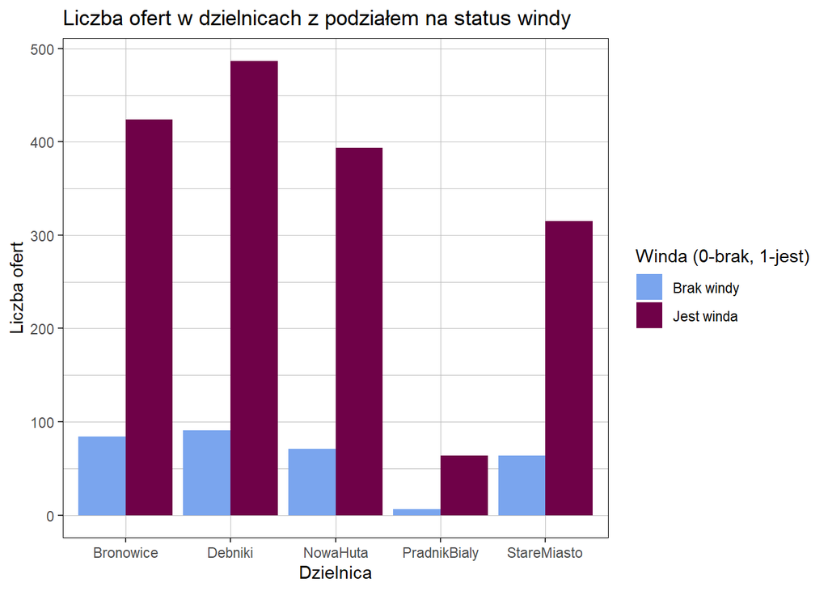

[output not shown]

```r
ggplot(dane, aes(x= dzielnica, fill = winda))+
  geom_bar(position="dodge")+
  scale_fill_manual(
    values = c("0" = "#7AA5EE", "1" = "#6F0148"),
    labels = c("Brak windy", "Jest winda")
  ) +
  labs(title = "Liczba ofert w dzielnicach z podziałem na status windy",
    x = "Dzielnica",
    y = "Liczba ofert",
    fill = "Winda (0-brak, 1-jest)")+
  theme(
    panel.background = element_rect(fill="white"),
    panel.border = element_rect(color = "black", size = 0.2, fill = NA),
    panel.grid.major = element_line(color = "grey", size = 0.2),
    panel.grid.minor = element_line(color = "grey", size = 0.25)
  )
```

# Histogram ceny mieszkań

## Zadania

- Stwórz histogram dla ceny mieszkań, dodając linię reprezentującą jądrowy estymator gęstości oraz przerywane linie oznaczające średnią i medianę.
- Oznacz osie, nadaj tytuł, zmień kolory histogramu oraz linii i dodaj legendę (legendy powinny uwzględniać styl linii, np. przerywana linia w legendzie odpowiada przerywanej linii na wykresie).
- Określ charakterystykę rozkładu: modalność, skośność i symetryczność.

## Rozwiązania

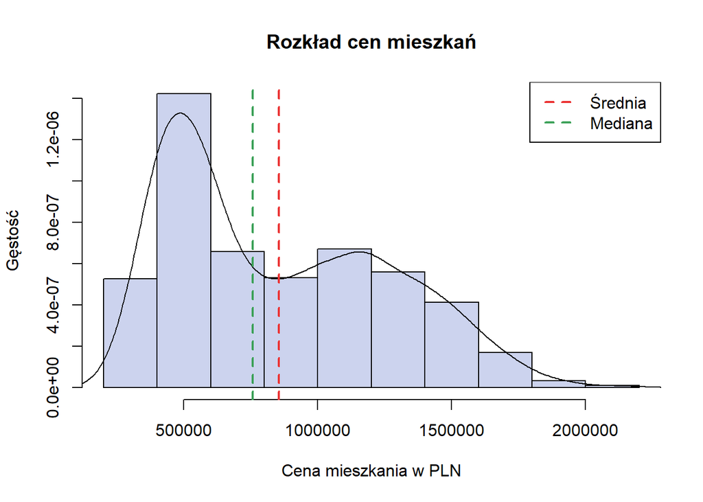

```r
mean_price = mean(dane$cena)
median_price = median(dane$cena)
#plot(density(dane$cena))
hist(dane$cena, main="Rozkład cen mieszkań", xlab="Cena mieszkania w PLN", ylab="Gęstość", col="#CCD3EE", , probability=TRUE)
lines(density(dane$cena))
abline(v = mean_price, col = "#eb3434", lwd = 2, lty = 2)
abline(v = median_price, col = "#3CA158", lwd = 2, lty = 2)
legend("topright",
       legend = c("Średnia", "Mediana"),
       col = c("#eb3434", "#3CA158"),
       lwd = 2,
       lty = 2)
```

```r
skewness(dane$cena)
```

```
## [1] 0.5252862
```

```r
kurtosis(dane$cena)
```

```
## [1] 2.176728
```

```
Jest to rozkład asymetryczny, prawoskośny z ogonem wyciągniętym w prawo i średnią większą niż mediana.Jest to niesymetryczny rozkład bimodalny, czyli posiadający dwie mody: jedną dla watości około 500 000 zł, drugą dla wartości ponad 1 000 000 zł.
```

# Wykresy pudełkowe dla powierzchni mieszkania vs. piętro

## Zadania

- Przy użyciu `ggplot2`, narysuj wykresy pudełkowe dla powierzchni mieszkania z podziałem kolorem na status parkingu (jest czy nie ma) oraz z podziałem na osobne panele ze względu na piętro.

## Rozwiązania

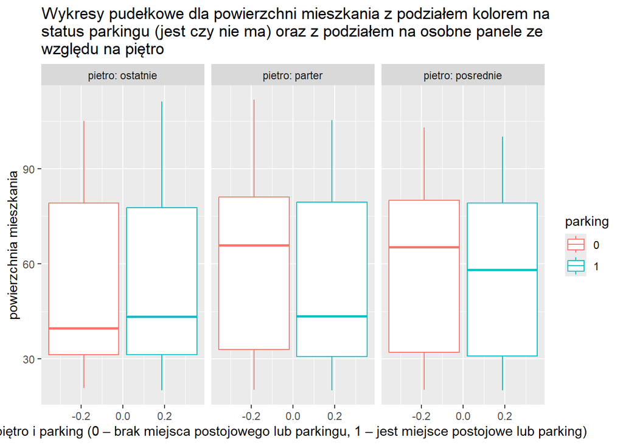

```r
ggplot(dane, aes( y=powierzchnia, color=parking))+
  geom_boxplot()+
  labs(title="Wykresy pudełkowe dla powierzchni mieszkania z podziałem kolorem na \nstatus parkingu (jest czy nie ma) oraz z podziałem na osobne panele ze \nwzględu na piętro", x="piętro i parking (0 – brak miejsca postojowego lub parkingu, 1 – jest miejsce postojowe lub parking) ", y="powierzchnia mieszkania")+
  facet_grid(~pietro, labeller=label_both)
```

# Analiza rozkładu ceny mieszkań dla najliczniej reprezentowanej dzielnicy

## Zadania

- Wybierz ceny mieszkań dla najliczniej reprezentowanej dzielnicy
- Przeprowadź analizę rozkładu: na podstawie wykresu Cullen and Frey wybierz i porównaj trzy różne rozkłady, wyestymuj ich parametry i oceń dopasowanie za pomocą wykresów QQplot oraz kryteriów informacyjnych.

Rodziny rozkładów: wykładniczy `exp`, logarytmiczno-normalny `lnorm`, gamma `gamma`, normalny `norm`, t-Studenta `t`, Weibulla `weibull`, beta `beta`, jednostajny `unif`

## Rozwiązania

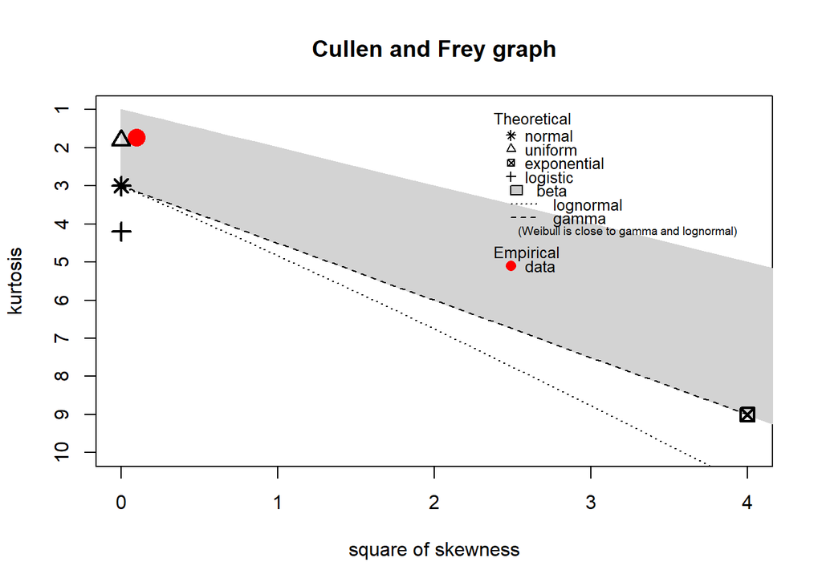

```
## summary statistics
## ------
## min:  292593.1   max:  1794455
## median:  768954.8
## mean:  860622.5
## estimated sd:  385620
## estimated skewness:  0.3154816
## estimated kurtosis:  1.724195
```

```r
n_dzielnica = names(which.max(table(dane$dzielnica)))
ceny_n = dane$cena[dane$dzielnica == n_dzielnica]
value = ceny_n
#hist(value, breaks = 30)
descdist(value, discrete = FALSE)
```

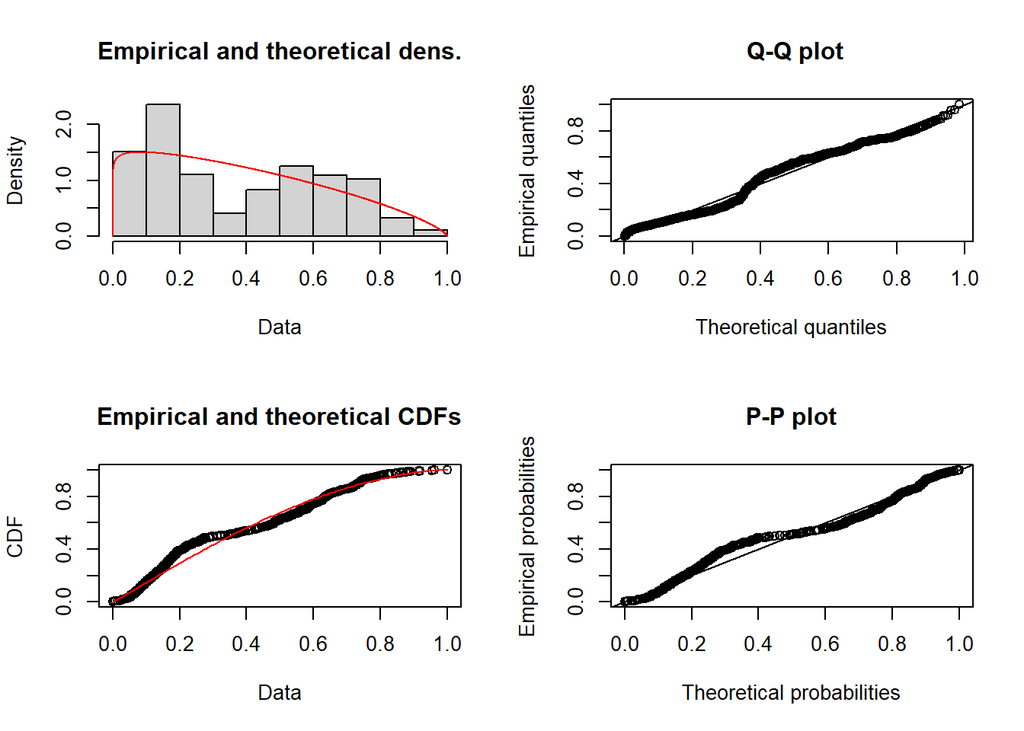

```r
normalize <- function(x) {
  return((x - min(x)) / (max(x) - min(x)))
}

normalized_value <- normalize(value)
normalized_value[normalized_value==0]=0.00001
normalized_value[normalized_value==1]=0.99999

fit_beta <- fitdist(normalized_value, "beta")
plot(fit_beta)
```

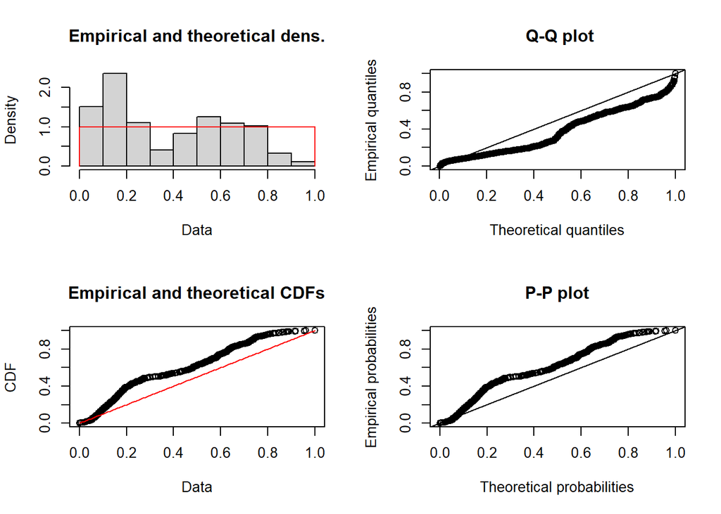

```r
fit_unif <- fitdist(normalized_value, "unif")
plot(fit_unif)
```

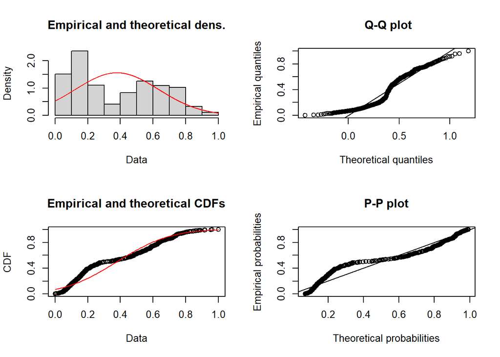

```r
fit_norm <- fitdist(normalized_value, "norm")
plot(fit_norm)
```

```r
gof_results1 <- gofstat(list(fit_beta, fit_unif), fitnames = c("Beta", "Jedostajny"))
gof_results2 <- gofstat(list(fit_beta, fit_norm), fitnames = c( "Beta", "Normalny"))
print(gof_results1)
```

```
## Goodness-of-fit statistics
##                                  Beta Jedostajny
## Kolmogorov-Smirnov statistic 0.100103  0.2117727
## Cramer-von Mises statistic   1.326265 10.5771194
## Anderson-Darling statistic   7.096029        Inf
##
## Goodness-of-fit criteria
##                                     Beta Jedostajny
## Akaike's Information Criterion -119.2302    3.97688
## Bayesian Information Criterion -110.5110   12.69603
```

```r
print(gof_results2)
```

```
## Goodness-of-fit statistics
##                                  Beta   Normalny
## Kolmogorov-Smirnov statistic 0.100103  0.1545418
## Cramer-von Mises statistic   1.326265  3.2437002
## Anderson-Darling statistic   7.096029 18.5627752
##
## Goodness-of-fit criteria
##                                     Beta Normalny
## Akaike's Information Criterion -119.2302 71.58476
## Bayesian Information Criterion -110.5110 80.30391
```

[output not shown]

# Analiza regresji

## Zadania

Zbuduj model regresji liniowej badający zależność:

`cena ~ powierzchnia + odleglosc_od_sklepu+odleglosc_od_przystanku`

Zinterpretuj (opisz ich istotność):

- współczynniki regresji,
- istotność modelu.

Sprawdź założenia modelu przy użyciu wykresów diagnostycznych i testów statystycznych. Opisz płynące z nich wnioski.

## Rozwiązania

```r
model_dane = lm(cena ~ powierzchnia + odleglosc_od_sklepu+odleglosc_od_przystanku, data=dane)
summary(model_dane)
```

```
##
## Call:
## lm(formula = cena ~ powierzchnia + odleglosc_od_sklepu + odleglosc_od_przystanku,
##     data = dane)
##
## Residuals:
##     Min      1Q  Median      3Q     Max
## -440152  -88582   -3692   82201  625937
##
## Coefficients:
##                          Estimate Std. Error t value Pr(>|t|)
## (Intercept)             -80134.82   25856.84  -3.099  0.00197 **
## powierzchnia             14621.51     121.88 119.969  < 2e-16 ***
## odleglosc_od_sklepu       1732.20      96.75  17.904  < 2e-16 ***
## odleglosc_od_przystanku   -186.74      14.63 -12.765  < 2e-16 ***
## ---
## Signif. codes:  0 '***' 0.001 '**' 0.01 '*' 0.05 '.' 0.1 ' ' 1
##
## Residual standard error: 137800 on 1996 degrees of freedom
## Multiple R-squared:  0.8869, Adjusted R-squared:  0.8868
## F-statistic:  5219 on 3 and 1996 DF,  p-value: < 2.2e-16
```

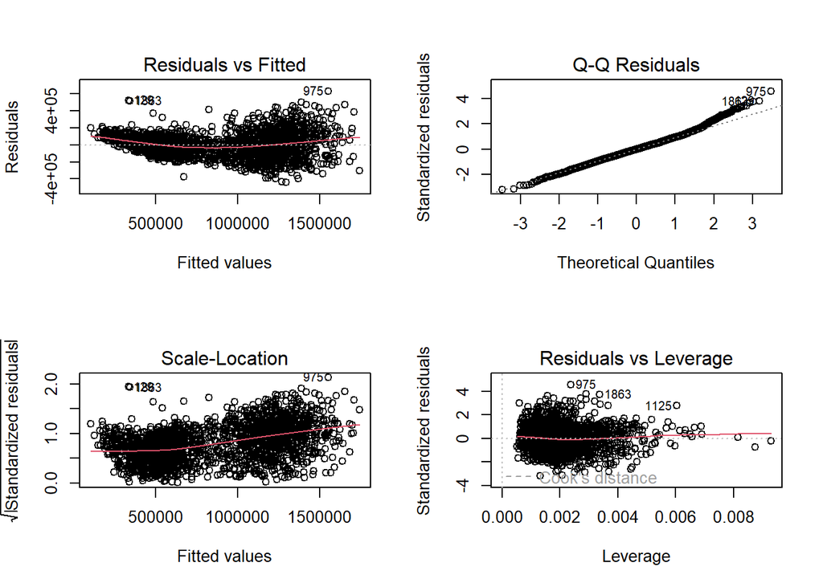

```r
par(mfrow=c(2,2))
plot(model_dane)
```

```r
bptest(model_dane)
```

```
##
##  studentized Breusch-Pagan test
##
## data:  model_dane
## BP = 310.22, df = 3, p-value < 2.2e-16
```

```r
durbinWatsonTest(model_dane)
```

```
##  lag Autocorrelation D-W Statistic p-value
##    1     0.002731961      1.994391   0.936
##  Alternative hypothesis: rho != 0
```

```r
shapiro.test(model_dane$residuals)
```

```
##
##  Shapiro-Wilk normality test
##
## data:  model_dane$residuals
## W = 0.99143, p-value = 1.824e-09
```

[output not shown]